# Problem_Set_4

Aaron

September 29, 2016

## Objective

The objective of this assignment is two fold. First you are required to read and summarize the key aspects of both readings *Cleveland and McGill 1985* and *Heer and Bostock 2010*. This summary should explore the similarities and differences in both studies approaches and in their findings.

To link what you learned from the perception research to your own graphics the second objective will be create and evaluate your own graphics. To do this create 4 different Vis idioms (line, bar, pie, tree…etc) using the data from `library(nycflights13)` and the `ggplot2` package. For each Vis that you create explain the graphic

1. Its core task (what you want to show)
2. Which graphical primitive is being assessed to understand this graphic and why did you choose each idiom used.
3. Example – Here is an example that shows NOT ONLY THE ANSWER but also my process.

The task of this graphic was to evaluate the average delay time of flights in and out of NYC. I was curious if there was a strong variability across months due the seasonality of weather in the northeast.

```r
# setup
library(dplyr)
```

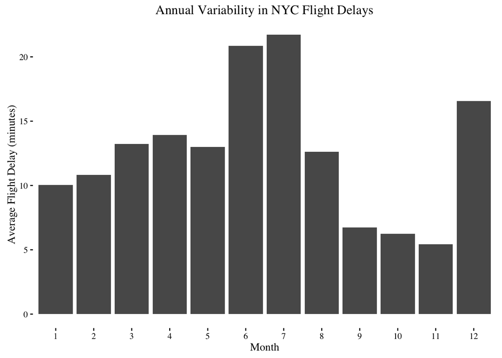

```r
library(ggplot2)
library(nycflights13)
# Load the data (abbreviate name for ease)
dat <- flights

# Manipulate data in prep for graphic
dat2 <- flights %>%
  select(month, dep_delay) %>%
  group_by(month) %>%
  summarise(delay = mean(dep_delay, na.rm = TRUE)) %>%
  as.data.frame()

# Create vis
ggplot(dat2, aes(factor(month),delay)) +
  geom_bar(stat= "identity") +
  xlab("Month") + ylab("Average Flight Delay (minutes)") +
  ggtitle("Annual Variability in NYC Flight Delays") +
  ggthemes::theme_tufte()
```

In this version I attempt to look at departure delay without summarizing the data, but rather looking at a smooth of the data across 2013. To use a bivariate approach I must treat `month` as a continuous variable.

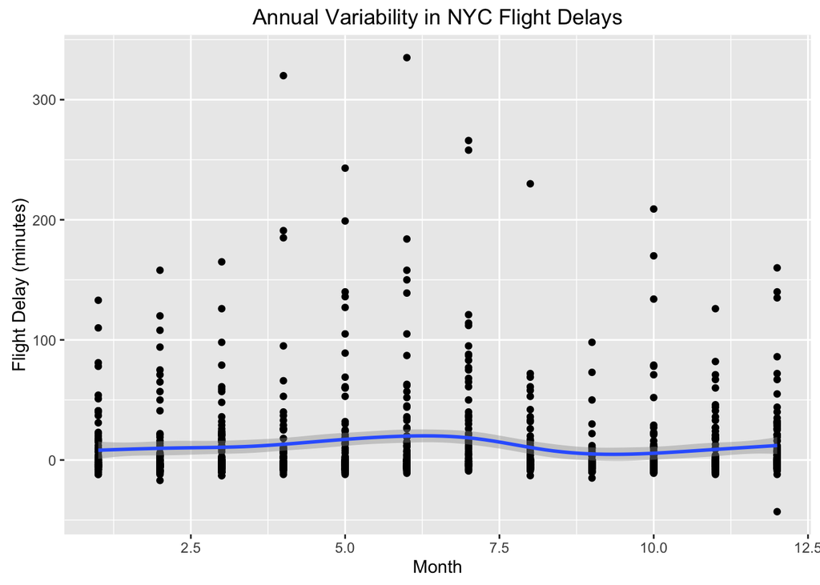

```r
# Manipulate data in prep for graphic
dat3 <- flights %>%
  sample_n(1000) %>%               # This dataset is large so I take a random sample
  select(month, dep_delay) %>%
  as.data.frame()

# Create vis
ggplot(dat3, aes(month,dep_delay)) +
  geom_point(na.rm = TRUE) +
  geom_smooth(na.rm = TRUE) +
  xlab("Month") + ylab("Flight Delay (minutes)") +
  ggtitle("Annual Variability in NYC Flight Delays")
```

But it due to the delay time range I can not really visualize the variability over time. I will try to correct that by eliminating the `geom_points()`

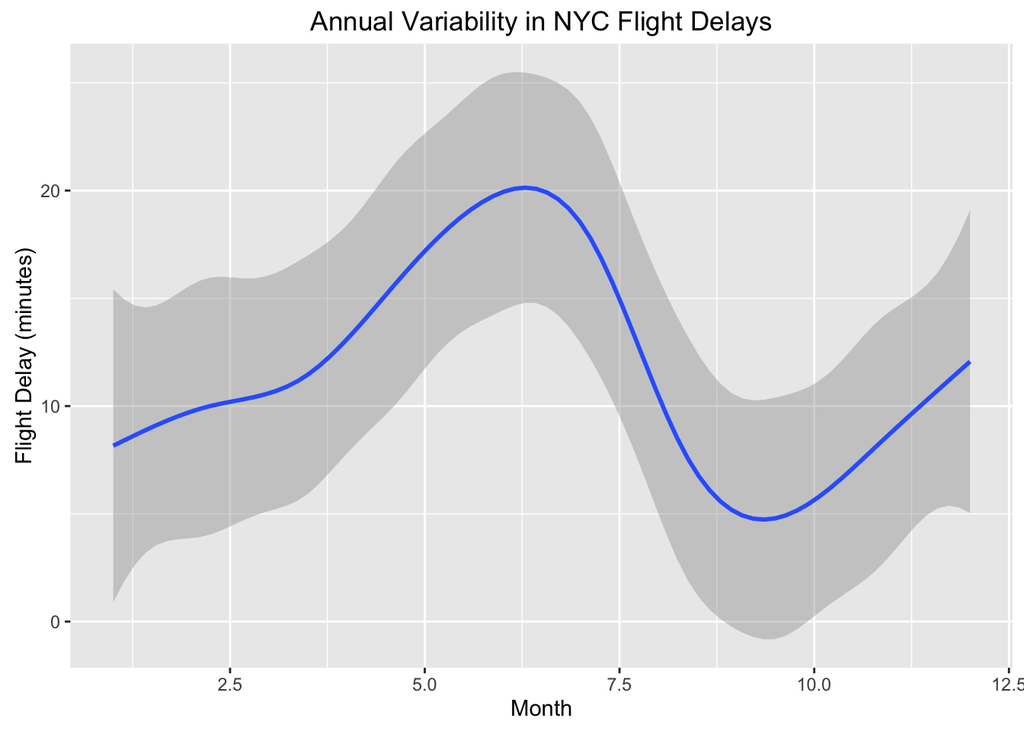

```r
# Create vis
ggplot(dat3, aes(month,dep_delay)) +
  #geom_point(na.rm = TRUE) +
  geom_smooth(na.rm = TRUE) +
  xlab("Month") + ylab("Flight Delay (minutes)") +
  ggtitle("Annual Variability in NYC Flight Delays")
```

Finally one more option to allow me to look at the raw data variability but not treat month as a continuous variable.

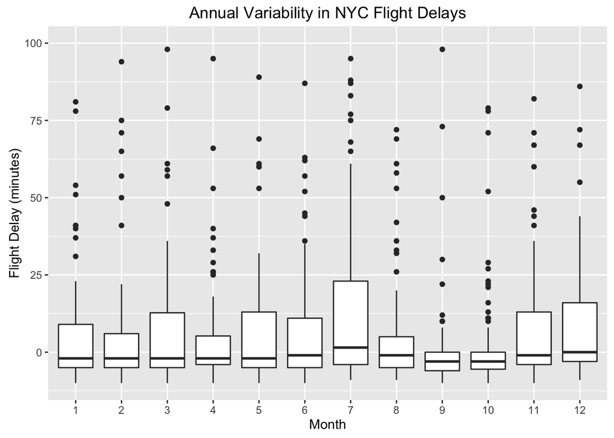

```r
# Create vis
ggplot(dat3, aes(factor(month),dep_delay)) +
  geom_boxplot() +
  xlab("Month") + ylab("Flight Delay (minutes)") +
  ylim(-10, 100) +
  ggtitle("Annual Variability in NYC Flight Delays")
```

Finally, the graphical primative that I am applying in each of these examples is *position along a common scale*. In my opinion the sheer size of this data makes it difficult to visualize the average differences between months without using a summary statistical approach. Given that caveat I think the most effective way to visualize mean departure delay by month was in my first graphic using a bar chart approach. I added a Tufte-ian theme to improve overall aesthetics using the package `ggthemes`